# R, RStudio and R Markdown

Yuji Saikai ysaikai@unimelb.edu.au School of Mathematics and Statistics The University of Melbourne

1 March 2021

# Programming in R

These notes are based on Chapter 3-5 of JMR — Jones, O., Maillardet, R., & Robinson, A. (2009). *Introduction to scientific programming and simulation using R*. CRC Press.

## `for` loop

### JMR 3.9.2

Let $h(x,n) = 1 + x + x^2+\dots+ x^n = \sum_{i=0}^n x^i$. Write an R program to calculate $h(x,n)$ using `for` loop.

```r
h <- function(x,n) {
  sum <- 0
  for (i in 0:n) {
    sum <- sum + x^i
  }
  return(sum)
}
```

### JMR 3.9.3

The function $h(x,n)$ from JMR 3.9.2 is the finite sum of a geometric sequence. It has the following explicit formula, for $x\neq1$,
$$h(x,n) = \frac{1-x^{n+1}}{1-x} .$$
Test your program from JMR 3.9.2 against this formula using the following values

| $x$ | $n$ | $h(x,n)$ | $\frac{1-x^{n+1}}{1-x}$ |
| --- | --- | --- | --- |
| 0.3 | 55 | 1.4285714 | 1.4285714 |
| 6.6 | 8 | 4.243335510^{6} | 4.243335510^{6} |

> You may use `format(h(6.6,8), scientific=FALSE)` for a nicer look.

## `while` loop

### JMR 3.9.4

First write a program that achieves the same result as in JMR 3.9.2 but using a `while` loop. Then write a program that does this using vector operations (and no loops).

```r
h2 <- function(x,n) {
  sum <- 0
  i <- 0
  while (i <= n) {
    sum <- sum + x^i
    i <- i + 1
  }
  return(sum)
}
```

```r
x <- 6.6
n <- 8
h2(x,n)
```

```
## [1] 4243336
```

```r
sum(x^(1:n)) # Just one line!
```

```
## [1] 4243335
```

Vector operations are faster and cool. We should use them when performance is required (e.g., Size of the Mandelbrot set). But, if they run for a second or two, I recommend using loops to be explicit about what you are doing.

## `if` statement

### Are you prime?

Write a function that returns whether an integer $n\geq2$ is prime. (Recall that $n\geq2$ is prime if it has only two factors: $1$ and $n$.)

```r
prime <- function(n) {
  if (n > 2){
    for (m in 2:(n/2)) {
    # for (m in 2:(sqrt(n))) {
      if (n %% m == 0) {
        return(FALSE)
      }
    }
  }
  return(TRUE)
}
prime(7)
```

```
## [1] TRUE
```

> We may replace `n/2` with `sqrt(n)` and make it more efficient because if $n=m_1m_2$, at least one of $m_1$ and $m_2$ must be less than or equal to $\sqrt{n}$.

### JMR 3.9.8

How does program provided in JMR p.32 behave if `a2=0` and/or `a1=0`? Using `if` statements, modify the program so that it gives sensible answers for all possible (numerical) inputs.

```r
a2 <- 0
a1 <- 2
a0 <- 1
```

```r
discrim <- a1^2 - 4*a2*a0
if (discrim > 0) {
  roots <- c( (-a1 + sqrt(a1^2 - 4*a2*a0))/(2*a2),
              (-a1 - sqrt(a1^2 - 4*a2*a0))/(2*a2) )
} else {
  if (discrim == 0) {
    roots <- -a1/(2*a2)
  } else {
    roots <- c()
  }
}
roots
```

```
## [1]  NaN -Inf
```

When using the quadratic formula, a problematic case is `a2=0`, which makes the function no longer quadratic but linear. So, let’s separate this case using `if`.

```r
if (a2 != 0) {
  if (discrim > 0) {
    roots <- c( (-a1 + sqrt(a1^2 - 4*a2*a0))/(2*a2),
                (-a1 - sqrt(a1^2 - 4*a2*a0))/(2*a2) )
  } else {
    if (discrim == 0) {
      roots <- -a1/(2*a2)
    } else {
      roots <- c()
    }
  }
} else if (a1 != 0) {
  roots <- -a0/a1
} else {
  roots <- c()
}
roots
```

```
## [1] -0.5
```

## Plotting

For practice, let’s draw a hyperbolic tangent with three fixed points at $x = 0, \pm1.915$.
$$y = 2\tanh(x) = 2\frac{e^{x}-e^{-x}}{e^{x}+e^{-x}}$$

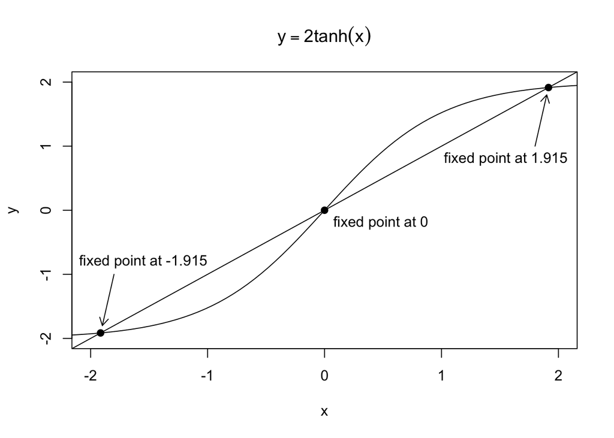

```r
x <- c(-1.915,0,1.915)
y <- c(-1.915,0,1.915)
plot(x, y, pch = 19, xlim=c(-2,2), ylim=c(-2,2))
title(expression(y==2*tanh(x)))
curve(2*tanh(x), from=-3, to=3, add=TRUE)
curve(x*1, from=-3, to=3, add=TRUE)
text(-1.55, -.8, "fixed point at -1.915")
text(0, -.2, "fixed point at 0", pos=4)
text(1.55, .8, "fixed point at 1.915")
arrows(-1.8, -1, -1.9, -1.8, length=0.1)
arrows(1.8, 1, 1.9, 1.8, length=0.1)
```

# RStudio

The interface of RStudio may look like this.

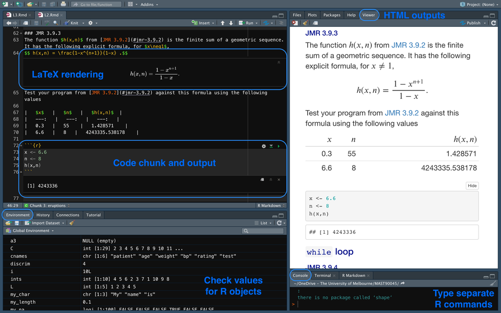

Pretty much everything can be done without leaving RStudio.

# R Markdown

These notes are based on [*Xie, Y., Allaire, J. J., & Grolemund, G. (2018). R markdown: The definitive guide. CRC Press.*](https://bookdown.org/yihui/rmarkdown/)

## Markdown syntax

To me, the Markdown motto is “Simplistic yet good enough”. Don’t forget to use line breaks generously to avoid unintended outputs. The following are some of Markdown syntax of heavy use.

### Headings

Just like Microsoft Word, [headings in Markdown](https://bookdown.org/yihui/rmarkdown/markdown-syntax.html#block-level-elements) not only produce section titles but also help to generate TOC (table of contents). For example, this section has a third-level header (`### Headings`), which appears in TOC.

### List

Start each item with `-` followed by a space at a line. For example,

```
- Item 1
- Item 2
- ...
```

produces

- Item 1
- Item 2
- …

### Link

To attach a “url” to a “text”, write `[text](url)`. For example,

`[The University of Melbourne](https://www.unimelb.edu.au)`

produces [The University of Melbourne](https://www.unimelb.edu.au).

An image is inserted in a similar way. For example, `![](images/rstudio.png)` (i.e., adding `!` in front). We often leave empty inside the brackets `[ ]`.

### Indentation

Just use `>` and a space . For example,

```
> This is indented.
```

produces

> This is indented.

### Code

[Inline code](https://bookdown.org/yihui/rmarkdown/markdown-syntax.html#inline-formatting) is produced by putting code inside `` ` ` `` like `` `code here` ``.

## YAML meta data

YAML (a recursive acronym for “YAML Ain’t Markup Language”) is used at the top of R Markdown script for a [header](https://ourcodingclub.github.io/tutorials/rmarkdown/#identify) that specifies meta data for the document. This document’s YAML header looks as follows.

```
---
title: "R, RStudio and R Markdown"
author: |
  |
  | Yuji Saikai
  | ysaikai@unimelb.edu.au
  | School of Mathematics and Statistics
  | The University of Melbourne
output:
  html_document:
    toc: true
    toc_float: true
    code_folding: show
    css: styles.css
---
```

## Code chunks

This is where R code is written. A code chunk may look as follows.

````markdown
```{r}
x <- 5 # 1st line of your R code.
y <- x^2 # 2nd line of your R code.
```
````

Conveniently, we can run the code without leaving the Markdown script. Just put the cursor somewhere in the chunk and press `Cmd + Shift + Return` (`Ctrl + Shift + Enter` on Linux and Windows).

We can provide many parameters inside `{r}` to specify how the code behaves and is itself displayed in the generated document. For example, `{r, include=FALSE}` means that the code is run but nothing shows up in the document.

Besides code chunks, we can also insert values of R objects and one-line computation as an inline text. A consequence is that we need not and indeed should not separately copy and paste results of our analysis. For example, a sentence “It predicts the score equal to 97.” should be written as:

```
It predicts the score equal to `r x`.
```

where the value `97` is stored in `x`. If we update the analysis thereby the value of `x` (e.g., `x=97` to `x=88`), then the value in the output document will be automatically updated. This is a key feature of R Markdown for “reproducibility”, an idea much advocated in scientific communities. (See [replication crisis](https://www.vox.com/future-perfect/21504366/science-replication-crisis-peer-review-statistics).)

We use this feature in JMR 3.9.3 above. To render the table, the source has

```
| $x$ | $n$ | $h(x,n)$ | $\frac{1-x^{n+1}}{1-x}$ |
| ---: | ---: | ---: | ---: |
| 0.3 | 55 | `r h(.3,55)` | `r (1-.3^56)/(1-.3)` |
| 6.6 | 8 | `r h(6.6,8)` | `r (1-6.6^9)/(1-6.6)` |
```

Much more detais are found [here](https://bookdown.org/yihui/rmarkdown/r-code.html).